# code

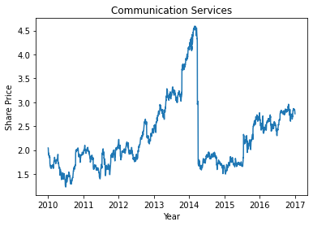

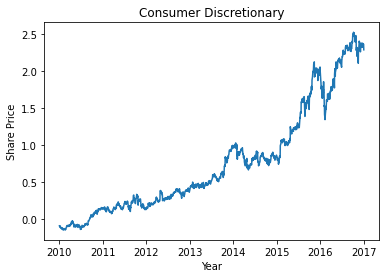

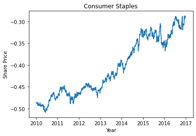

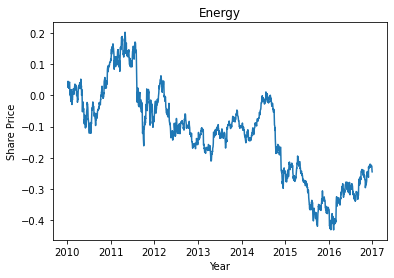

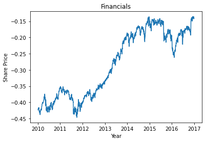

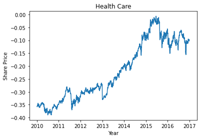

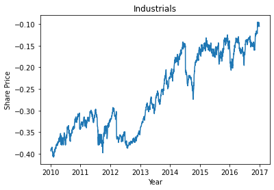

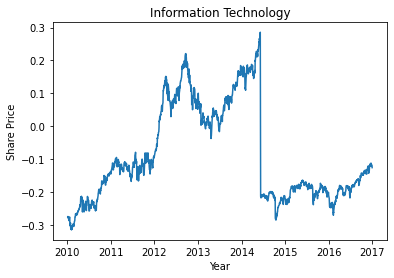

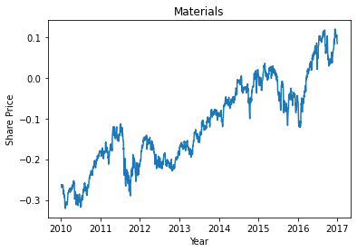

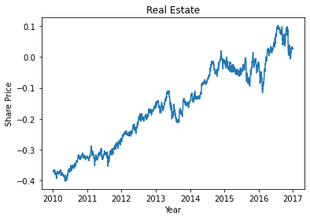

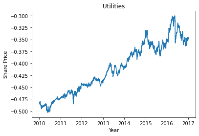

```python
for i, sector in np_scaled.groupby('sector'):
    mean = []
    for j, date in sector.groupby('date'):
        mean.append((j, date['close'].mean()))
    plt.plot(*zip(*mean))
    plt.xlabel('Year')
    plt.ylabel('Share Price')
    plt.title(i)
    plt.show()
```

Some markets have consistently underpreformed compared to others. Meaning, if a shareholder held stock in both a Consumer Discretionary company and an Industrials company in 2010, both shares would increase in value on average by 2017, but the Consumer Discretionary company would increase at a much greater rate.

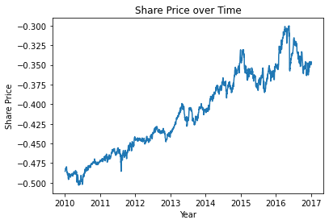

```python
mean = []
for j, date in sector.groupby('date'):
    mean.append((j, date['close'].mean()))
plt.plot(*zip(*mean))
plt.xlabel('Year')
plt.ylabel('Share Price')
plt.title('Share Price over Time')
plt.show()
```

Could use fundamentals for regression. Use Earnings per Share as y, and all other variables as X (drop For Year column first). Use summary table to determine what variables significantly affect earnings per share, and can communicate that to the reader as to what important info to look for when researching stocks Could also use that to model future EPS values, and indicate to the reader that those companies are forecasted to increase in price if data stays consistent and baring outside circumstances